# notebook1

## CMSC320 Final Tutorial: Airline Customer Satisfaction

##### Collaborators: Vyshnav Kandamath, Ronoy Sarkar, Alexander Dong

### Introduction

In this tutorial, we will explore the entire data science pipeline. We will start with data collection and processing, leading into an explatory analysis, then hypothesis testing with machine learning. Finally we will finish our conclusion and main takeways from our analysis.

We have chosen to focus on Airline Customer Satisfaction. Airline companies want to maximize customer satisfaction to bolster company reputations in the hopes of improving business. However, there are thousands of airline customers and countless factors that can influence their satisfaction. Using data science, we are able to analyze large amounts of data to understand what influences customer satisfaction the most and how to improve on it. The information gathered from this data science process is highly valuable for not only airline companies but all companies who want to understand their customer base, build costumer loyalty, and how to best improve on their product.

This is an important topic in general because it can allow airlines to adjust their services based on what is most likely to make flyers satisfied. This promotes greater service, makes the industry more competitive, and will lead to better experiences overall. This is also an important topic in a data science context as it contains a very large dataset with many different types of data (categorical, numerical, etc.). This diverse dataset makes it a very interesting problem to try and develop recommendations and insights.

### 1. Data Collection / Processing

To look at airline costumer satisfaction, we must first find a database that contains airline specific information on a large quantity of costumers, such as loyalty, flight amenities, flight path information, etc. We decided to use a Kaggle dataset for this tutorial. The exact link to the dataset can be found at https://www.kaggle.com/datasets/raminhuseyn/airline-customer-satisfaction. In order to download the data, we selected the black download button in the top right which saves the file Airline_customer_satisfaction.

The dataset was downloaded in .csv format (in this tutorial, we simply named it data.csv). Using a csv file makes it easier for us to understand the data when looking at it and to process it with our tools. We will be using various Python libraries in a Juptyer notebook. We started our Jupyter Notebook in the same directory. To collect and process our data, we import the Python libraries pandas, which allows us to manipulate data, and numpy, which gives us tools to work with large, multi-dimensional datasets.

To learn how to install and setup jupyter notebook, you can use the following link: https://jupyter.org/install

```python
import pandas as pd
import numpy as np
df = pd.read_csv("data.csv")
df.head()
```

|  | satisfaction | Customer Type | Age | Type of Travel | Class | Flight Distance | Seat comfort | Departure/Arrival time convenient | Food and drink | Gate location | ... | Online support | Ease of Online booking | On-board service | Leg room service | Baggage handling | Checkin service | Cleanliness | Online boarding | Departure Delay in Minutes | Arrival Delay in Minutes |
| --- | --- | --- | --- | --- | --- | --- | --- | --- | --- | --- | --- | --- | --- | --- | --- | --- | --- | --- | --- | --- | --- |
| 0 | satisfied | Loyal Customer | 65 | Personal Travel | Eco | 265 | 0 | 0 | 0 | 2 | ... | 2 | 3 | 3 | 0 | 3 | 5 | 3 | 2 | 0 | 0.0 |
| 1 | satisfied | Loyal Customer | 47 | Personal Travel | Business | 2464 | 0 | 0 | 0 | 3 | ... | 2 | 3 | 4 | 4 | 4 | 2 | 3 | 2 | 310 | 305.0 |
| 2 | satisfied | Loyal Customer | 15 | Personal Travel | Eco | 2138 | 0 | 0 | 0 | 3 | ... | 2 | 2 | 3 | 3 | 4 | 4 | 4 | 2 | 0 | 0.0 |
| 3 | satisfied | Loyal Customer | 60 | Personal Travel | Eco | 623 | 0 | 0 | 0 | 3 | ... | 3 | 1 | 1 | 0 | 1 | 4 | 1 | 3 | 0 | 0.0 |
| 4 | satisfied | Loyal Customer | 70 | Personal Travel | Eco | 354 | 0 | 0 | 0 | 3 | ... | 4 | 2 | 2 | 0 | 2 | 4 | 2 | 5 | 0 | 0.0 |

5 rows × 22 columns

## Initial Observations

We can immediately see that there are a number of columns in this dataset. The 'satisfaction' value is a binary classification of whether an individual was happy with their airline experience. The other columns contain various datatypes representing metrics associated with someone's experience with the airline. However, we can't tell from this whether there are missing values or portions of the data that are incomplete. Thus, we are going to run two important functions tell us the amount of entries for each column and the number of null values.

1) The first function we will run is df.info(). This tells us a summary of all columns, what type is stored in the column, and the number of non-null values. This is helpful in identifying rows that are missing values, as the counts will be different. 2) The second function we will run is df.isnull().sum(). This tells us how many null values are in a column, which helps us figure out parts of the data that need to be changed or dropped.

```python
df.info()
```

```
<class 'pandas.core.frame.DataFrame'>
RangeIndex: 129880 entries, 0 to 129879
Data columns (total 22 columns):
 #   Column                             Non-Null Count   Dtype
---  ------                             --------------   -----
 0   satisfaction                       129880 non-null  object
 1   Customer Type                      129880 non-null  object
 2   Age                                129880 non-null  int64
 3   Type of Travel                     129880 non-null  object
 4   Class                              129880 non-null  object
 5   Flight Distance                    129880 non-null  int64
 6   Seat comfort                       129880 non-null  int64
 7   Departure/Arrival time convenient  129880 non-null  int64
 8   Food and drink                     129880 non-null  int64
 9   Gate location                      129880 non-null  int64
 10  Inflight wifi service              129880 non-null  int64
 11  Inflight entertainment             129880 non-null  int64
 12  Online support                     129880 non-null  int64
 13  Ease of Online booking             129880 non-null  int64
 14  On-board service                   129880 non-null  int64
 15  Leg room service                   129880 non-null  int64
 16  Baggage handling                   129880 non-null  int64
 17  Checkin service                    129880 non-null  int64
 18  Cleanliness                        129880 non-null  int64
 19  Online boarding                    129880 non-null  int64
 20  Departure Delay in Minutes         129880 non-null  int64
 21  Arrival Delay in Minutes           129487 non-null  float64
dtypes: float64(1), int64(17), object(4)
memory usage: 21.8+ MB
```

From the info() function we can see that most columns have the same number of values (129880), with the exception of Arrival Delay in minutes.

```python
df.isnull().sum()
```

```
satisfaction                           0
Customer Type                          0
Age                                    0
Type of Travel                         0
Class                                  0
Flight Distance                        0
Seat comfort                           0
Departure/Arrival time convenient      0
Food and drink                         0
Gate location                          0
Inflight wifi service                  0
Inflight entertainment                 0
Online support                         0
Ease of Online booking                 0
On-board service                       0
Leg room service                       0
Baggage handling                       0
Checkin service                        0
Cleanliness                            0
Online boarding                        0
Departure Delay in Minutes             0
Arrival Delay in Minutes             393
dtype: int64
```

From this we can see that Arrival Delay in Minutes has 393 missing values, which we now need to change.

## Cleaning Data

Based on the above, we can see the dataset is not as clean as we would like. Thus, we can take a couple steps before data analysis to make it easier for us. A usual issue with datasets is that there is missing data, represented as NaNs. Since our dataset is very large, we don't want to check every entry to see if there are any missing values, so we clean it up by dropping all the NaNs using dropna(). Then we will re-run the above functions to ensure that it works.

```python
df_cleaned = df.dropna()
na_check_after_cleaning = df_cleaned.isnull().sum()
na_check_after_cleaning, df_cleaned.shape
df_cleaned.info()
```

```
<class 'pandas.core.frame.DataFrame'>
Int64Index: 129487 entries, 0 to 129879
Data columns (total 22 columns):
 #   Column                             Non-Null Count   Dtype
---  ------                             --------------   -----
 0   satisfaction                       129487 non-null  object
 1   Customer Type                      129487 non-null  object
 2   Age                                129487 non-null  int64
 3   Type of Travel                     129487 non-null  object
 4   Class                              129487 non-null  object
 5   Flight Distance                    129487 non-null  int64
 6   Seat comfort                       129487 non-null  int64
 7   Departure/Arrival time convenient  129487 non-null  int64
 8   Food and drink                     129487 non-null  int64
 9   Gate location                      129487 non-null  int64
 10  Inflight wifi service              129487 non-null  int64
 11  Inflight entertainment             129487 non-null  int64
 12  Online support                     129487 non-null  int64
 13  Ease of Online booking             129487 non-null  int64
 14  On-board service                   129487 non-null  int64
 15  Leg room service                   129487 non-null  int64
 16  Baggage handling                   129487 non-null  int64
 17  Checkin service                    129487 non-null  int64
 18  Cleanliness                        129487 non-null  int64
 19  Online boarding                    129487 non-null  int64
 20  Departure Delay in Minutes         129487 non-null  int64
 21  Arrival Delay in Minutes           129487 non-null  float64
dtypes: float64(1), int64(17), object(4)
memory usage: 22.7+ MB
```

This did work as it removed all null values and all columns have the same number now. This dataset was relatively simple and was fairly clean initially. However, this will not always be the case. In those instances you will have to use more advanced data cleaning techniques. Here is a link to help you learn more: https://realpython.com/python-data-cleaning-numpy-pandas/

## Exploratory Data Analysis / Visualization

Now that our data has been cleaned, our next step is to perform Exploratory Data Analysis, where we find information about the dataset and develop visualizations to clearly see relationships in the data. We want to be able to identify things that immediately stand out about our dataset.

We can begin with the pandas describe function provides a lot of useful statistics about the dataset. This gives us a lot of information about measured of central tendency and can be useful for numeric data values.

```python
df_cleaned.describe()
```

|  | Age | Flight Distance | Seat comfort | Departure/Arrival time convenient | Food and drink | Gate location | Inflight wifi service | Inflight entertainment | Online support | Ease of Online booking | On-board service | Leg room service | Baggage handling | Checkin service | Cleanliness | Online boarding | Departure Delay in Minutes | Arrival Delay in Minutes |
| --- | --- | --- | --- | --- | --- | --- | --- | --- | --- | --- | --- | --- | --- | --- | --- | --- | --- | --- |
| count | 129487.000000 | 129487.000000 | 129487.000000 | 129487.000000 | 129487.000000 | 129487.000000 | 129487.000000 | 129487.000000 | 129487.000000 | 129487.000000 | 129487.000000 | 129487.000000 | 129487.000000 | 129487.000000 | 129487.000000 | 129487.000000 | 129487.000000 | 129487.000000 |
| mean | 39.428761 | 1981.008974 | 2.838586 | 2.990277 | 2.852024 | 2.990377 | 3.249160 | 3.383745 | 3.519967 | 3.472171 | 3.465143 | 3.486118 | 3.695460 | 3.340729 | 3.705886 | 3.352545 | 14.643385 | 15.091129 |
| std | 15.117597 | 1026.884131 | 1.392873 | 1.527183 | 1.443587 | 1.305917 | 1.318765 | 1.345959 | 1.306326 | 1.305573 | 1.270755 | 1.292079 | 1.156487 | 1.260561 | 1.151683 | 1.298624 | 37.932867 | 38.465650 |
| min | 7.000000 | 50.000000 | 0.000000 | 0.000000 | 0.000000 | 0.000000 | 0.000000 | 0.000000 | 0.000000 | 0.000000 | 0.000000 | 0.000000 | 1.000000 | 0.000000 | 0.000000 | 0.000000 | 0.000000 | 0.000000 |
| 25% | 27.000000 | 1359.000000 | 2.000000 | 2.000000 | 2.000000 | 2.000000 | 2.000000 | 2.000000 | 3.000000 | 2.000000 | 3.000000 | 2.000000 | 3.000000 | 3.000000 | 3.000000 | 2.000000 | 0.000000 | 0.000000 |
| 50% | 40.000000 | 1924.000000 | 3.000000 | 3.000000 | 3.000000 | 3.000000 | 3.000000 | 4.000000 | 4.000000 | 4.000000 | 4.000000 | 4.000000 | 4.000000 | 3.000000 | 4.000000 | 4.000000 | 0.000000 | 0.000000 |
| 75% | 51.000000 | 2543.000000 | 4.000000 | 4.000000 | 4.000000 | 4.000000 | 4.000000 | 4.000000 | 5.000000 | 5.000000 | 4.000000 | 5.000000 | 5.000000 | 4.000000 | 5.000000 | 4.000000 | 12.000000 | 13.000000 |
| max | 85.000000 | 6951.000000 | 5.000000 | 5.000000 | 5.000000 | 5.000000 | 5.000000 | 5.000000 | 5.000000 | 5.000000 | 5.000000 | 5.000000 | 5.000000 | 5.000000 | 5.000000 | 5.000000 | 1592.000000 | 1584.000000 |

One visualization that can be very helpful is a heatmap. This allows one to use changes in colors to easily visualize variables that are strongly correlated. To do this we utilized the seaborn library and the .corr() function. This is very helpful in identifying correlation but it's important to remember this does not always indicate a causal relationship. Still, we can observe things such as the strong correlation between the ease of online booking and online boarding.

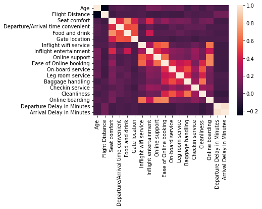

```python
import seaborn as sns
sns.heatmap(df_cleaned.corr())
```

### Basic Visualization of Some Features

We want to first see how the features exist individually, before we relate them to satisfaction. This will allow us to see whether the population of the dataset is skewed towards particular types of customers. This would have to be taken into account.

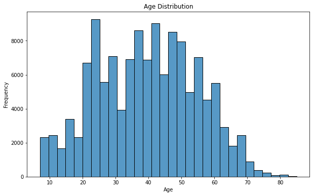

```python
plt.figure(figsize=(10, 6))
sns.histplot(df_cleaned['Age'], bins=30)
plt.title('Age Distribution')
plt.xlabel('Age')
plt.ylabel('Frequency')
plt.show()
```

The above plot shows us the distribution of ages in the dataset. It is not a normal distribution but it doesn't seem to be particularly skewed either. It has bimodal, which we can see from the two peaks. Next lets look at customer type.

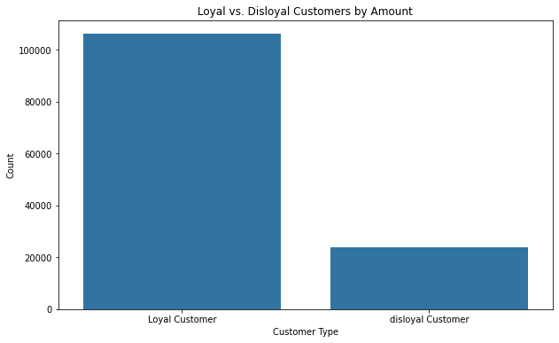

```python
plt.figure(figsize=(10, 6))
sns.countplot(data=df, x='Customer Type')
plt.title('Loyal vs. Disloyal Customers by Amount')
plt.xlabel('Customer Type')
plt.ylabel('Count')
plt.show()
```

This tells us that a lot of people who chose to respond to this survey are loyal customers. This is important to note because it indicates they may have strong preferences regarding the airline relative to other flyers. We can examine the class differences present like this.

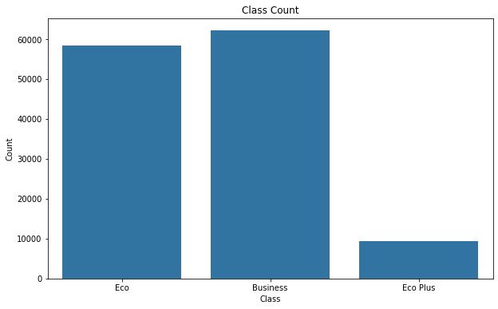

```python
plt.figure(figsize=(10, 6))
sns.countplot(data=df, x='Class')
plt.title('Class Count')
plt.xlabel('Class')
plt.ylabel('Count')
plt.show()
```

This shows there are very few economy plus flyers but there is not a huge difference in the number of Eco and Business class showing the dataset is quite balanced in this regard. However, business class is generally much smaller in a general flight so they are overrepresented in this survey.

Now we will continue visualizing but this type try to find relationships between different features rather than simply counting them.

We will use the Python library Matplotlib to help us visualize the data. This library provides us many tools to represent our data in various graphs, allowing us to explore our data visually. Lets first look at some key relationships. The first one is Customer Satisfactions by Type of Travel. It is helpful to use a bar graph to show how many responses of each category we have and how their satisfaction is overall. This provides two key datapoints and can be observed very quickly.

From the resulting chart, we notice that there are far more business travelers than personal travelers in the dataset and that business travelers have more than half of travelers saying they were satisfied, which is more than for the personal traveler population.

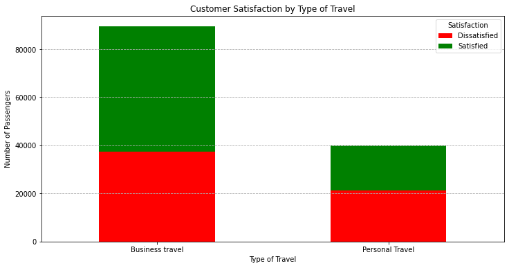

```python
import matplotlib.pyplot as plt

travel_satisfaction_counts = df_cleaned.groupby(['Type of Travel', 'satisfaction']).size().unstack()
class_satisfaction_counts = df_cleaned.groupby(['Class', 'satisfaction']).size().unstack()

# Plotting the satisfaction by type of travel
plt.figure(figsize=(12, 6))
travel_satisfaction_counts.plot(kind='bar', stacked=True, color=['red', 'green'], ax=plt.gca())
plt.title('Customer Satisfaction by Type of Travel')
plt.xlabel('Type of Travel')
plt.ylabel('Number of Passengers')
plt.xticks(rotation=0)
plt.legend(title='Satisfaction', labels=['Dissatisfied', 'Satisfied'])
plt.grid(axis='y', linestyle='--')

plt.show()
```

There seems to be a bit more satisfied than dissatisfied business travel costumers. The opposite is true for personal travel costumers, where there are a bit more dissatisfied costumers than satisfied ones. Maybe there is something about business travel that leads to more satisfied costumers?

The second visualization is Customer Satisfaction by Class they fly in. We can use another bar chart here to show the number of responses from each group as well as the results within each group. In this case we have three different groups.

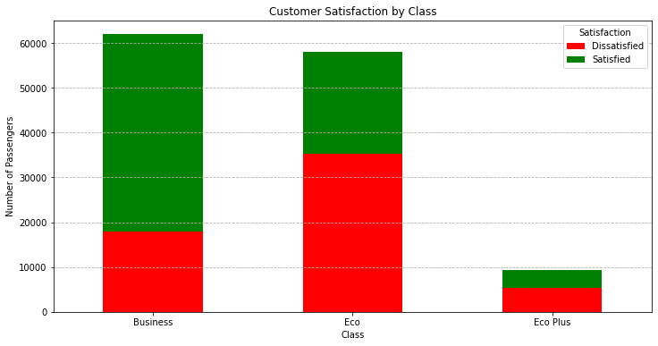

```python
plt.figure(figsize=(12, 6))
class_satisfaction_counts.plot(kind='bar', stacked=True, color=['red', 'green'], ax=plt.gca())
plt.title('Customer Satisfaction by Class')
plt.xlabel('Class')
plt.ylabel('Number of Passengers')
plt.xticks(rotation=0)
plt.legend(title='Satisfaction', labels=['Dissatisfied', 'Satisfied'])
plt.grid(axis='y', linestyle='--')

plt.show()
```

There are clear patterns found in this bar graph. The majority of business class customers are satisfied, while the majority of eco class and eco plus costumers are dissatisfied. There seems to be a distinction of customer satisfaction between different classes. This tips us off on what to explore further, as certain factors in business class seem to lead to more costumer satisfaction.

As our first step, lets analyze the various services offered and to get a general idea of what is important for airline customer satisfaction. We will identify variables that we think are important and group them together to be presented in a single graph.

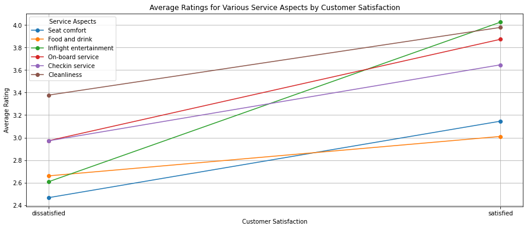

```python
columns_of_interest = ['Seat comfort', 'Food and drink', 'Inflight entertainment', 'On-board service', 'Checkin service', 'Cleanliness']
means_by_satisfaction = df_cleaned.groupby('satisfaction')[columns_of_interest].mean()

plt.figure(figsize=(15, 6))
for column in columns_of_interest:
    plt.plot(means_by_satisfaction.index, means_by_satisfaction[column], marker='o', label=column)

plt.title('Average Ratings for Various Service Aspects by Customer Satisfaction')
plt.xlabel('Customer Satisfaction')
plt.ylabel('Average Rating')
plt.legend(title='Service Aspects')
plt.grid(True)
plt.xticks(rotation=0)
plt.show()
```

This graph shows that satisfied customers generally gave higher scores for all of these values. The steeper the slops, the bigger the difference in responses. Inflight entertainment has the buggest jump while Food and Drink appears to have the least. The other four are relatively similar.

Lastly, we can explore the age groups of satisfied customers and visualize it using a Pie Chart. Pie charts allow us to see and understand proportions in data easily. We will group ages into three bins, labelled Young, Adult, and Senior. First, we will look at the age groups of satisfied customers.

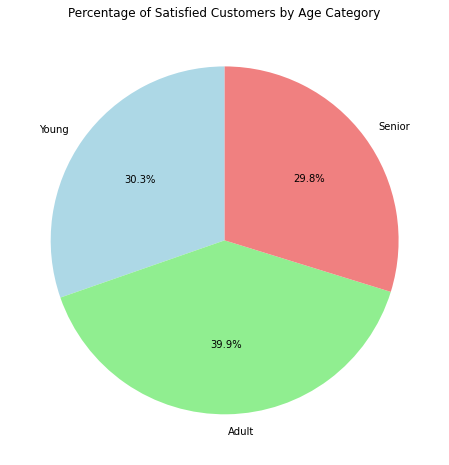

```python
df_cleaned['Age Category'] = pd.cut(df_cleaned['Age'], bins=[0, 18, 64, 100], labels=['Young', 'Adult', 'Senior'])

# Group by age category and satisfaction, then count
age_satisfaction_distribution = df_cleaned.groupby(['Age Category', 'satisfaction']).size().unstack()

# Calculate the percentage of satisfied customers in each age category
age_satisfaction_percentage = (age_satisfaction_distribution['satisfied'] / age_satisfaction_distribution.sum(axis=1)) * 100

# Plotting the pie chart
plt.figure(figsize=(8, 8))
age_satisfaction_percentage.plot(kind='pie', autopct='%1.1f%%', startangle=90, colors=['lightblue', 'lightgreen', 'lightcoral'])
plt.title('Percentage of Satisfied Customers by Age Category')
plt.ylabel('')
plt.show()
```

Among satisfied customers, the largest age group is Adults while the other two seem to be pretty even. However, the age split overall among satisfied customers is not too drastic.

Now we can grasp at the age category of dissatisfied customers

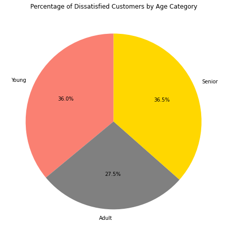

```python
age_dissatisfaction_percentage = (age_satisfaction_distribution['dissatisfied'] / age_satisfaction_distribution.sum(axis=1)) * 100

plt.figure(figsize=(8, 8))
age_dissatisfaction_percentage.plot(kind='pie', autopct='%1.1f%%', startangle=90, colors=['salmon', 'grey', 'gold'])
plt.title('Percentage of Dissatisfied Customers by Age Category')
plt.ylabel('')
plt.show()
```

This pie chart tells us the same information from the previous one but inverted, where we see that Adults are the least percentage of dissatisfied costumers while the other two are pretty even.

Next, we will look at Loyal and Disloyal customers and how that affects customer satisfaction

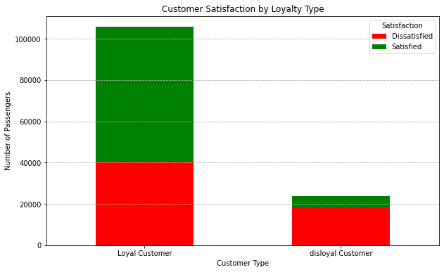

```python
loyalty_satisfaction_counts = df_cleaned.groupby(['Customer Type', 'satisfaction']).size().unstack()

# Creating the stacked bar chart
plt.figure(figsize=(10, 6))
loyalty_satisfaction_counts.plot(kind='bar', stacked=True, color=['red', 'green'], ax=plt.gca())
plt.title('Customer Satisfaction by Loyalty Type')
plt.xlabel('Customer Type')
plt.ylabel('Number of Passengers')
plt.xticks(rotation=0)
plt.legend(title='Satisfaction', labels=['Dissatisfied', 'Satisfied'])
plt.grid(axis='y', linestyle='--')

plt.show()
```

This bar graph tells us that the majority of loyal costumers are satisfied while the majority of disloyal customers are dissatisfied, which makes sense.

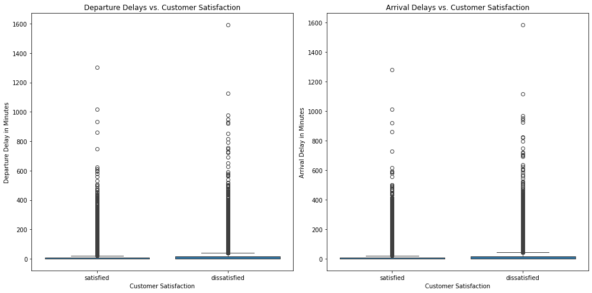

```python
import matplotlib.pyplot as plt
import seaborn as sns

# Setting up the data for box plots
delay_data = df_cleaned[['satisfaction', 'Departure Delay in Minutes', 'Arrival Delay in Minutes']]

# Creating box plots
plt.figure(figsize=(14, 7))
plt.subplot(1, 2, 1)
sns.boxplot(x='satisfaction', y='Departure Delay in Minutes', data=delay_data)
plt.title('Departure Delays vs. Customer Satisfaction')
plt.ylabel('Departure Delay in Minutes')
plt.xlabel('Customer Satisfaction')

plt.subplot(1, 2, 2)
sns.boxplot(x='satisfaction', y='Arrival Delay in Minutes', data=delay_data)
plt.title('Arrival Delays vs. Customer Satisfaction')
plt.ylabel('Arrival Delay in Minutes')
plt.xlabel('Customer Satisfaction')

plt.tight_layout()
plt.show()
```

Here is one with flight distance and customer satisfaction.

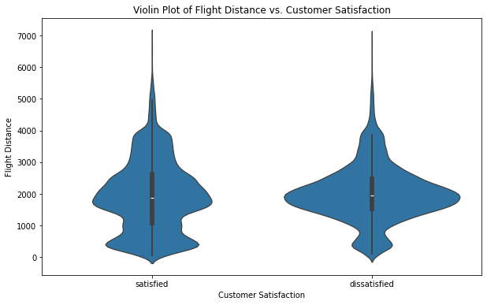

```python
plt.figure(figsize=(10, 6))
sns.violinplot(x='satisfaction', y='Flight Distance', data=df_cleaned)
plt.title('Violin Plot of Flight Distance vs. Customer Satisfaction')
plt.xlabel('Customer Satisfaction')
plt.ylabel('Flight Distance')
plt.show()
```

Let us see how flight distance can relate with another variable, for example, class.

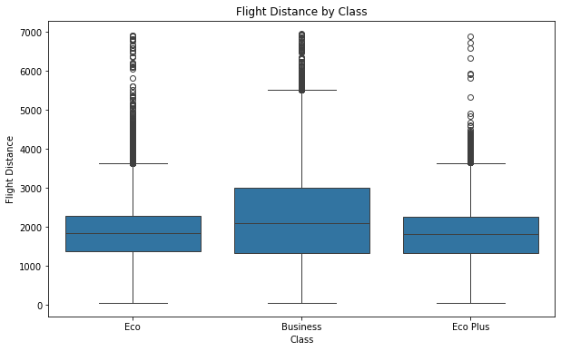

```python
plt.figure(figsize=(10, 6))
sns.boxplot(data=df, x='Class', y='Flight Distance')
plt.title('Flight Distance by Class')
plt.xlabel('Class')
plt.ylabel('Flight Distance')
plt.show()
```

This is very interesting as while the ranges are the same, the business class has a much greater range in the middle 50% of their dataset indicating they generally take longer flights. Let's see if this is related to age at all:

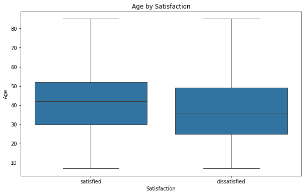

```python
plt.figure(figsize=(10, 6))
sns.boxplot(data=df, x='satisfaction', y='Age')
plt.title('Age by Satisfaction')
plt.xlabel('Satisfaction')
plt.ylabel('Age')
plt.show()
```

By contrast, there is very little difference between these two groups.

Now a correlation heat map! Using degrees of color, we can see the strength of relationships between variables with all other variables to understand which correlation is...most correlated.

For this one, unlike the first, we are going to be using just the numerical columns and are have adjusted the color scheme to make it more readable.

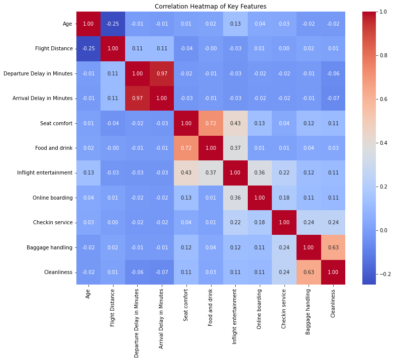

```python
numerical_columns = ['Age', 'Flight Distance', 'Departure Delay in Minutes', 'Arrival Delay in Minutes',
                     'Seat comfort', 'Food and drink', 'Inflight entertainment', 'Online boarding',
                     'Checkin service', 'Baggage handling', 'Cleanliness']

# Creating the correlation matrix
correlation_matrix = df_cleaned[numerical_columns].corr()

# Generating the heatmap
plt.figure(figsize=(12, 10))
sns.heatmap(correlation_matrix, annot=True, fmt=".2f", cmap='coolwarm', cbar=True)
plt.title('Correlation Heatmap of Key Features')
plt.show()
```

The correlation heat map suggests that arrival and departure delays are heavily correlated with eachother, as well as seat comfort and food and drink. This tells us that delays are an important variable to look at as well as in-flight amenities. In addition, baggage handling and cleanliness seem to be correlated with each other so they could be other factors to look at.

## Model: Analysis, Hypothesis Testing, Machine Learning

### Imports, Identify Features, Convert Categorical Features to Binary, Split into Training and Testing Set

Now that we have explored and visualized our data, we can create models and use machine learning to test our hypotheses about airline costumer satisfaction. The Python library we will be using is scikit-learn which gives us simple and efficient machine learning tools.

The goal in this analysis will be to develop a model to predict whether a customer will be satisfied or not given the other variables.

To build this model, we will have to partitition the dataset into a testing and training set. We will train the model and the score it based on its performance with the testing set.

```python
import pandas as pd
from sklearn.model_selection import train_test_split
from sklearn.linear_model import LogisticRegression
from sklearn.svm import SVC
from sklearn.neighbors import KNeighborsClassifier
from sklearn.metrics import confusion_matrix


features = ['Flight Distance', 'Age', 'Departure Delay in Minutes', 'Arrival Delay in Minutes',
            'Customer Type', 'Type of Travel', 'Class']
X_full = df_cleaned[features]
Y_full = df_cleaned['satisfaction'] == 'satisfied'  # Converting to binary
X_full = pd.get_dummies(X_full)


# Split data into training and testing sets
X_train_full, X_test_full, Y_train_full, Y_test_full = train_test_split(X_full, Y_full, test_size=0.2, random_state=42)
```

In the above code sample, after importing the necessary modules we split our data into four categories: x-training, x-testing, y-training, and y-testing. The test_size value shows that 0.2 or 20% of the data will be allocated for testing while the remaining data points will be used for training.

### Model One: Logistic Regression

This model uses logistic regression for the prediction. The link to the full sklearn model can be found here: https://scikit-learn.org/stable/modules/generated/sklearn.linear_model.LogisticRegression.html

To assess the model we are creating two charts:

1) A confusion matrix - this will show the correct labels versus the predicted labels for the dataset and indicate how the model classified them. We want to minimize the number of incorrect labels (false negatives and positives)

2) A scatterplot of predictions versus output - this will plot the points based on the predicted value and actual value

```
Logistic Regression Accuracy: 0.69
```

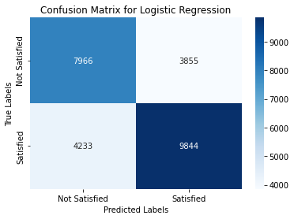

[figure not shown]

```python
log_reg = LogisticRegression(max_iter=1000)
log_reg.fit(X_train_full, Y_train_full)
log_reg_score = log_reg.score(X_test_full, Y_test_full)

print (f"Logistic Regression Accuracy: {log_reg_score:.2f}")

# Confusion Matrix
predictions = log_reg.predict(X_test_full)
cm = confusion_matrix(Y_test_full, predictions)
cm_display = sns.heatmap(cm, annot=True, cmap='Blues', fmt='g', xticklabels=['Not Satisfied', 'Satisfied'], yticklabels=['Not Satisfied', 'Satisfied'])
plt.xlabel('Predicted Labels')
plt.ylabel('True Labels')
plt.title('Confusion Matrix for Logistic Regression')
plt.show()

# Scatter Plot
plt.figure(figsize=(10, 6))
plt.scatter(log_reg.predict_proba(X_test_full)[:, 1], Y_test_full, alpha=0.5, color='blue')
plt.title('Predicted Probabilities vs. Actual Outcomes')
plt.xlabel('Predicted Probability of Satisfaction')
plt.ylabel('Actual Outcome')
plt.yticks([0, 1], ['Not Satisfied', 'Satisfied'])
plt.grid(True)
plt.show()
```

The accuracy of the model is 0.69 which is not extremely high. The confusion matrix shows that there are a lot of false negatives in the model. This indicates that this is not a very strong model and does a relatively poor job predicting the output. We can try to implement a different type of model and see whether we can improve upon this.

### Model Two: KNN

This model will be the KNN or K-Nearest Neighbors classification. You can read the documentation for this at https://scikit-learn.org/stable/modules/generated/sklearn.neighbors.KNeighborsClassifier.html

```
KNN Best Accuracy: 0.61 at k=18
```

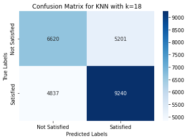

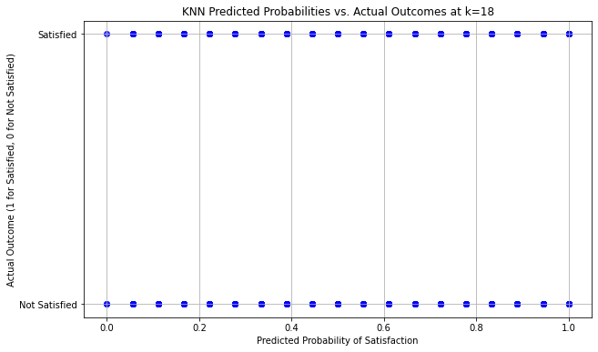

```python
best_k = 0
best_score = 0
for k in range(1, 21):
    knn = KNeighborsClassifier(n_neighbors=k)
    knn.fit(X_train_full, Y_train_full)
    k_score = knn.score(X_test_full, Y_test_full)
    if k_score > best_score:
        best_k = k
        best_score = k_score

print (f"KNN Best Accuracy: {best_score:.2f} at k={best_k}")

# Confusion Matrix
best_knn = KNeighborsClassifier(n_neighbors=best_k)
best_knn.fit(X_train_full, Y_train_full)
predictions = best_knn.predict(X_test_full)
cm = confusion_matrix(Y_test_full, predictions)
sns.heatmap(cm, annot=True, cmap='Blues', fmt='g', xticklabels=['Not Satisfied', 'Satisfied'], yticklabels=['Not Satisfied', 'Satisfied'])
plt.xlabel('Predicted Labels')
plt.ylabel('True Labels')
plt.title(f'Confusion Matrix for KNN with k={best_k}')
plt.show()

# Scatter Plot
try:
    probabilities = best_knn.predict_proba(X_test_full)[:, 1]
except AttributeError:
    probabilities = predictions
plt.figure(figsize=(10, 6))
plt.scatter(probabilities, Y_test_full, alpha=0.5, color='blue')
plt.title(f'KNN Predicted Probabilities vs. Actual Outcomes at k={best_k}')
plt.xlabel('Predicted Probability of Satisfaction')
plt.ylabel('Actual Outcome (1 for Satisfied, 0 for Not Satisfied)')
plt.yticks([0, 1], ['Not Satisfied', 'Satisfied'])
plt.grid(True)
plt.show()
```

This has a slightly lower accuracy at 0.61. The best accuracy was achieved at k=18. The correlation matrix shows more false positives than false negatives this time and the model did not perform that well overall. The scatterplot shows almost no distinction between the two groups. Based on this, the logistic regression model is a better model but neither of the models developed are extremely accurate.

## Conclusion

Through this exploration we went through the full data science pipleline in order to try and gain insights from the dataset and learn more about what makes people satisfied with their airline. We began with data collection and cleaned it. Then we performed a lot of initial analysis and generated visualizations in order to learn more about the data. Finally, we built two different models and compared their results with a correlation matrix and a scatterplot. Based on the findings we would have to look into different models to recommend definitive changes as an airline as we were not able to achieve a very high accuracy. However, we can still indicate that some of the features we found to be significant in the exploratory data analysis, such as class and service aspects, have heavy correlation with their satisfaction and experience.

To learn more about data science we recommend the following website: https://www.geeksforgeeks.org/whats-data-science-pipeline/

Thank you for following along with this tutorial!